# Data Aggregations and Group Operations

```python
import pandas as pd
import numpy as np
```

In this lab, you will work a dataset that belongs to a MOOC. The dataset contains the following columns:

- **StudentId**: Id of the student
- **Age**: The age of the student
- **Education**: The education level of the student. 1: Highschool, 2: Undergrad, 3: Master, 4: PhD.
- **Exam1**: First midterm score [ranges between 0 to 100]
- **Exam2**: Second midterm score [ranges between 0 to 100]
- **Final**: Final exam score [ranges between 0 to 100]
- **Discussion**: Number of discussion posts
- **Tutorial**: Number of visits to tutorial pages
- **Video**: Number of views of course videos
- **Assignment**: Number of assignments submitted [ranges between 0 to 4].

**TASK 1** Import the data into a dataframe called `data`, and display the top 3 rows:

```python
data = pd.read_excel('student-data.xlsx', index_col=None)
print(data.head(3))
```

```
   StudentId  Age  Education  Exam1  Exam2  Final  Discussion  Tutorial  \
0         10   23          1   45.0     55   60.0           1        16
1         72   16          1   65.0     33   40.0           3         5
2         82   17          1   68.0     48   35.0           3         8

   Video  Assignment
0     13           2
1      7           2
2     20           2
```

**TASK 2** There are some missing values in some columns. Display the count of missing values per each column.

The output should look like this:

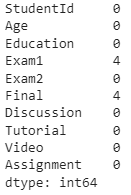

```python
missing_value = data.isnull().sum()
print(missing_value)
```

```
StudentId     0
Age           0
Education     0
Exam1         4
Exam2         0
Final         4
Discussion    0
Tutorial      0
Video         0
Assignment    0
dtype: int64
```

**TASK 3** Fill the missing values in `Exam1` column with the average `Exam1` of the `Education` level that the student belongs to.

For example, assume that student A's `Exam1` score is unknown. This student's education level is *Higher Education*. Then, the `Exam1` score of this student should be set to the average `Exam1` score of all students from *Higher Education*.

```python
average_exam1 = data.groupby('Education')['Exam1'].transform('mean')
data['Exam1'].fillna(average_exam1, inplace=True)
```

**TASK 4** Fill the missing values in `Final` column with the student's average score in `Exam1` and `Exam2`. In this task the education level does not matter.

HINT: You can simply use `fillna` method on `Final` column (no `apply` or `lambda` function is necessary).

```python
data['Final'] = data['Final'].fillna(data[['Exam1', 'Exam2']].mean(axis=1))
print(data.head(20))
```

```
    StudentId  Age  Education      Exam1  Exam2  Final  Discussion  Tutorial  \
0          10   23          1  45.000000     55   60.0           1        16
1          72   16          1  65.000000     33   40.0           3         5
2          82   17          1  68.000000     48   35.0           3         8
3          83   20          1  29.000000     24   42.0           2        20
4          93   24          1  54.000000     37   61.0           0         5
5         111   22          1  50.000000     61   62.0           1        17
6         118   18          1  64.000000     33   55.0           2        12
7         127   24          1  39.000000     31   23.0           3         5
8         128   16          1  34.000000     26   20.0           1        16
9         151   18          1  54.000000     61   55.0           2        13
10        161   16          1  57.000000     58   43.0           3        15
11        172   17          1  47.682353     68   45.0           0        11
12        181   15          1  21.000000     56   65.0           0        13
13        184   23          1  69.000000     51   50.0           2        11
```

[output cut: 28 more lines]

**TASK 5** In this task, you need to replace the values in `Education` column with proper labels, given in the following dictionary:

```python
educationDict = { 1: '1.Highschool', 2:'2.Undergrad', 3:'3.Master', 4:'4.PhD' }
```

Now, pass this dictionary into `replace` function, to update the values in the `Education` column:

```python
data['Education'] = data['Education'].replace(educationDict)
print(data.head(2))
```

```
   StudentId  Age     Education  Exam1  Exam2  Final  Discussion  Tutorial  \
0         10   23  1.Highschool   45.0     55   60.0           1        16
1         72   16  1.Highschool   65.0     33   40.0           3         5

   Video  Assignment
0     13           2
1      7           2
```

**TASK 6** Now, we are interested in if there is a difference in exam performances depending on the education level.

Please use `groupby` to compute the average scores of *Exam1*, *Exam2*, and *Final* for each `Education` level.

```python
average_scores = data.groupby('Education')['Exam1', 'Exam2', 'Final'].mean()

print(average_scores)
```

```
                  Exam1      Exam2      Final
Education
1.Highschool  47.682353  44.912791  44.712209
2.Undergrad   60.123596  70.402235  75.064246
3.Master      78.535135  78.720430  78.639785
4.PhD         80.461988  79.228070  79.745614
```

**TASK 7**: Based on the dataset obtained in the previous task, please find for which Education level there is an increase in the average scores from Exam1 to Exam2 and from Exam2 to Final.

Here, you can utilize `pct_change` function.

The output of your code should look like this:

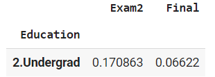

```python
percentage_change = average_scores.pct_change(axis=1)
print(percentage_change[['Exam2', 'Final']])
```

```
                 Exam2     Final
Education
1.Highschool -0.058084 -0.004466
2.Undergrad   0.170958  0.066220
3.Master      0.002359 -0.001024
4.PhD        -0.015335  0.006532
```

```python
print(percentage_change.loc['2.Undergrad', ['Exam2', 'Final']])
```

```
Exam2    0.170958
Final    0.066220
Name: 2.Undergrad, dtype: float64
```

**TASK 8** The `Assignment` column indicates the number of submissions submitted by the students (between 0-4). It is expected that students who submit their assignments will show better performance in the final exam.

To explore this relationship, please compute the average `Final` grade for each distinct vauel of `Assignment` column.

```python
average_final_by_assignment = data.groupby('Assignment')['Final'].mean()
print(average_final_by_assignment)
```

```
Assignment
0    47.675000
1    62.811224
2    71.639474
3    74.575916
4    71.283069
Name: Final, dtype: float64
```

**TASK 9** In this task, the goal is to construct a new dataframe that has two columns:

- `ExamAvg` (the average of `Exam1`, `Exam2`, and `Final`)
- `Visits` (the average of the `Tutorial` and `Video` columns).

You should use `groupby` function and pass a dictionary (possibly called *mapping*) to this function.

Below is a sample view from the output:

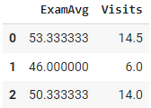

```python
data['ExamAvg'] = data[['Exam1', 'Exam2', 'Final']].mean(axis=1)
data['Visits'] = data[['Tutorial', 'Video']].mean(axis=1)
result_df = data[['ExamAvg', 'Visits']]
print(result_df.head())
```

```
     ExamAvg  Visits
0  53.333333    14.5
1  46.000000     6.0
2  50.333333    14.0
3  31.666667    16.5
4  50.666667     7.5
```

**TASK 10** Create four bins (or buckets) from the existing data based on students' final grades. The lower-upper boundries for each bin are provided below, along with the labels:

- 0-59: Fails
- 60-69: Low Performers
- 70-84: Medium Performers
- 85-100: High Performers

The expected output is provided below:

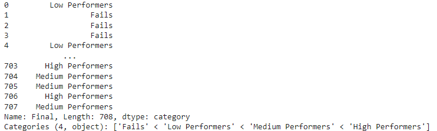

```python
bins = [0, 59, 69, 84, 100]
labels = ['Fails', 'Low Performers', 'Medium Performers', 'High Performers']
data['Grade'] = pd.cut(data['Final'], bins=bins, labels=labels, include_lowest=True)
print(data['Grade'])
```

```
0         Low Performers
1                  Fails
2                  Fails
3                  Fails
4         Low Performers
             ...
703      High Performers
704    Medium Performers
705    Medium Performers
706      High Performers
707    Medium Performers
Name: Grade, Length: 708, dtype: category
Categories (4, object): ['Fails' < 'Low Performers' < 'Medium Performers' < 'High Performers']
```

**TASK 11** In the following several tasks, we are interested in exploring if students' age has any effect on their performance.

First, create a equal-length 4 buckets based on the ages of the students.

The output should look like this:

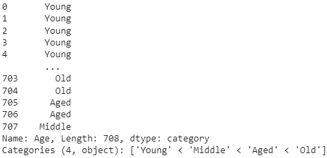

```python
age_labels = ['Young', 'Middle', 'Aged', 'Old']
data['AgeGroup'] = pd.cut(data['Age'], bins=4, labels=age_labels, include_lowest=True)
print(data['AgeGroup'])
```

```
0       Young
1       Young
2       Young
3       Young
4       Young
        ...
703       Old
704       Old
705      Aged
706      Aged
707    Middle
Name: AgeGroup, Length: 708, dtype: category
Categories (4, object): ['Young' < 'Middle' < 'Aged' < 'Old']
```

**TASK 12** Next, group data based on age categories, and compute the followings:

- Exam1, Exam2: *Average*,
- Discussion Tutorial Video: *Average, Minimum value, and Maximum Value*

The output should look like this:

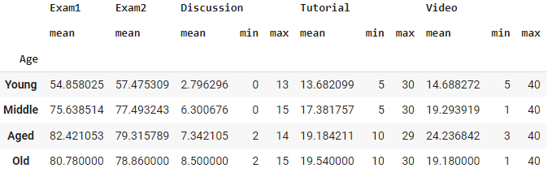

```python
result = data.groupby('AgeGroup').agg({
    'Exam1': ['mean'],
    'Exam2': ['mean'],
    'Discussion': ['mean', 'min', 'max'],
    'Tutorial': ['mean', 'min', 'max'],
    'Video': ['mean', 'min', 'max']
})

result.columns = result.columns.map('_'.join)
print(result)
```

```
          Exam1_mean  Exam2_mean  Discussion_mean  Discussion_min  \
AgeGroup
Young      54.847186   57.475309         2.796296               0
Middle     75.636943   77.493243         6.300676               0
Aged       82.421053   79.315789         7.342105               2
Old        80.780000   78.860000         8.500000               2

          Discussion_max  Tutorial_mean  Tutorial_min  Tutorial_max  \
AgeGroup
Young                 13      13.682099             5            30
Middle                15      17.381757             5            30
Aged                  14      19.184211            10            29
Old                   15      19.540000            10            30

          Video_mean  Video_min  Video_max
AgeGroup
Young      14.688272          5         40
Middle     19.293919          1         40
Aged       24.236842          3         40
Old        19.180000          1         40
```